# Visualización y Curación de Datos

Natalia Moreno

# Trabajo Práctico 2

```r
# install.packages("mclust")
```

Para este trabajo práctico se trabaja el dataset mtcars

Inspeccionamos el dataset:

```r
data("mtcars")
mtcars
```

|  | mpg | cyl | disp | hp | drat | wt | qsec | vs | am | gear | carb |
| --- | --- | --- | --- | --- | --- | --- | --- | --- | --- | --- | --- |
| Mazda RX4 | 21.0 | 6 | 160.0 | 110 | 3.90 | 2.620 | 16.46 | 0 | 1 | 4 | 4 |
| Mazda RX4 Wag | 21.0 | 6 | 160.0 | 110 | 3.90 | 2.875 | 17.02 | 0 | 1 | 4 | 4 |
| Datsun 710 | 22.8 | 4 | 108.0 | 93 | 3.85 | 2.320 | 18.61 | 1 | 1 | 4 | 1 |
| Hornet 4 Drive | 21.4 | 6 | 258.0 | 110 | 3.08 | 3.215 | 19.44 | 1 | 0 | 3 | 1 |
| Hornet Sportabout | 18.7 | 8 | 360.0 | 175 | 3.15 | 3.440 | 17.02 | 0 | 0 | 3 | 2 |
| Valiant | 18.1 | 6 | 225.0 | 105 | 2.76 | 3.460 | 20.22 | 1 | 0 | 3 | 1 |
| Duster 360 | 14.3 | 8 | 360.0 | 245 | 3.21 | 3.570 | 15.84 | 0 | 0 | 3 | 4 |
| Merc 240D | 24.4 | 4 | 146.7 | 62 | 3.69 | 3.190 | 20.00 | 1 | 0 | 4 | 2 |
| Merc 230 | 22.8 | 4 | 140.8 | 95 | 3.92 | 3.150 | 22.90 | 1 | 0 | 4 | 2 |
| Merc 280 | 19.2 | 6 | 167.6 | 123 | 3.92 | 3.440 | 18.30 | 1 | 0 | 4 | 4 |

[output cut: 22 more lines]

```r
# Agrego las marcas como columna, por si es necesario utilizar mas adelante pero no lo usamos
cars<-subset(mtcars)
cars$names <- rownames(cars)
cars
```

|  | mpg | cyl | disp | hp | drat | wt | qsec | vs | am | gear | carb | names |
| --- | --- | --- | --- | --- | --- | --- | --- | --- | --- | --- | --- | --- |
| Mazda RX4 | 21.0 | 6 | 160.0 | 110 | 3.90 | 2.620 | 16.46 | 0 | 1 | 4 | 4 | Mazda RX4 |
| Mazda RX4 Wag | 21.0 | 6 | 160.0 | 110 | 3.90 | 2.875 | 17.02 | 0 | 1 | 4 | 4 | Mazda RX4 Wag |
| Datsun 710 | 22.8 | 4 | 108.0 | 93 | 3.85 | 2.320 | 18.61 | 1 | 1 | 4 | 1 | Datsun 710 |
| Hornet 4 Drive | 21.4 | 6 | 258.0 | 110 | 3.08 | 3.215 | 19.44 | 1 | 0 | 3 | 1 | Hornet 4 Drive |
| Hornet Sportabout | 18.7 | 8 | 360.0 | 175 | 3.15 | 3.440 | 17.02 | 0 | 0 | 3 | 2 | Hornet Sportabout |
| Valiant | 18.1 | 6 | 225.0 | 105 | 2.76 | 3.460 | 20.22 | 1 | 0 | 3 | 1 | Valiant |
| Duster 360 | 14.3 | 8 | 360.0 | 245 | 3.21 | 3.570 | 15.84 | 0 | 0 | 3 | 4 | Duster 360 |
| Merc 240D | 24.4 | 4 | 146.7 | 62 | 3.69 | 3.190 | 20.00 | 1 | 0 | 4 | 2 | Merc 240D |
| Merc 230 | 22.8 | 4 | 140.8 | 95 | 3.92 | 3.150 | 22.90 | 1 | 0 | 4 | 2 | Merc 230 |
| Merc 280 | 19.2 | 6 | 167.6 | 123 | 3.92 | 3.440 | 18.30 | 1 | 0 | 4 | 4 | Merc 280 |

[output cut: 22 more lines]

```r
# Observamos la dimensión del dataset:
dim(mtcars)
```

```
## [1] 32 11
```

```r
# El nombre de las columnas:
names(mtcars)
```

```
##  [1] "mpg"  "cyl"  "disp" "hp"   "drat" "wt"   "qsec" "vs"   "am"   "gear"
## [11] "carb"
```

```r
rownames(mtcars)
```

```
##  [1] "Mazda RX4"           "Mazda RX4 Wag"       "Datsun 710"
##  [4] "Hornet 4 Drive"      "Hornet Sportabout"   "Valiant"
##  [7] "Duster 360"          "Merc 240D"           "Merc 230"
## [10] "Merc 280"            "Merc 280C"           "Merc 450SE"
## [13] "Merc 450SL"          "Merc 450SLC"         "Cadillac Fleetwood"
## [16] "Lincoln Continental" "Chrysler Imperial"   "Fiat 128"
## [19] "Honda Civic"         "Toyota Corolla"      "Toyota Corona"
## [22] "Dodge Challenger"    "AMC Javelin"         "Camaro Z28"
## [25] "Pontiac Firebird"    "Fiat X1-9"           "Porsche 914-2"
## [28] "Lotus Europa"        "Ford Pantera L"      "Ferrari Dino"
## [31] "Maserati Bora"       "Volvo 142E"
```

```r
# La estructura de los datos:
str(mtcars)
```

```
## 'data.frame':    32 obs. of  11 variables:
##  $ mpg : num  21 21 22.8 21.4 18.7 18.1 14.3 24.4 22.8 19.2 ...
##  $ cyl : num  6 6 4 6 8 6 8 4 4 6 ...
##  $ disp: num  160 160 108 258 360 ...
##  $ hp  : num  110 110 93 110 175 105 245 62 95 123 ...
##  $ drat: num  3.9 3.9 3.85 3.08 3.15 2.76 3.21 3.69 3.92 3.92 ...
##  $ wt  : num  2.62 2.88 2.32 3.21 3.44 ...
##  $ qsec: num  16.5 17 18.6 19.4 17 ...
##  $ vs  : num  0 0 1 1 0 1 0 1 1 1 ...
##  $ am  : num  1 1 1 0 0 0 0 0 0 0 ...
##  $ gear: num  4 4 4 3 3 3 3 4 4 4 ...
##  $ carb: num  4 4 1 1 2 1 4 2 2 4 ...
```

```r
# Las principales medidas de la muestra:
summary(mtcars)
```

```
##       mpg             cyl             disp             hp
##  Min.   :10.40   Min.   :4.000   Min.   : 71.1   Min.   : 52.0
##  1st Qu.:15.43   1st Qu.:4.000   1st Qu.:120.8   1st Qu.: 96.5
##  Median :19.20   Median :6.000   Median :196.3   Median :123.0
##  Mean   :20.09   Mean   :6.188   Mean   :230.7   Mean   :146.7
##  3rd Qu.:22.80   3rd Qu.:8.000   3rd Qu.:326.0   3rd Qu.:180.0
##  Max.   :33.90   Max.   :8.000   Max.   :472.0   Max.   :335.0
##       drat             wt             qsec             vs
##  Min.   :2.760   Min.   :1.513   Min.   :14.50   Min.   :0.0000
##  1st Qu.:3.080   1st Qu.:2.581   1st Qu.:16.89   1st Qu.:0.0000
##  Median :3.695   Median :3.325   Median :17.71   Median :0.0000
##  Mean   :3.597   Mean   :3.217   Mean   :17.85   Mean   :0.4375
##  3rd Qu.:3.920   3rd Qu.:3.610   3rd Qu.:18.90   3rd Qu.:1.0000
##  Max.   :4.930   Max.   :5.424   Max.   :22.90   Max.   :1.0000
##        am              gear            carb
##  Min.   :0.0000   Min.   :3.000   Min.   :1.000
##  1st Qu.:0.0000   1st Qu.:3.000   1st Qu.:2.000
##  Median :0.0000   Median :4.000   Median :2.000
##  Mean   :0.4062   Mean   :3.688   Mean   :2.812
##  3rd Qu.:1.0000   3rd Qu.:4.000   3rd Qu.:4.000
##  Max.   :1.0000   Max.   :5.000   Max.   :8.000
```

## Mixturas de Gaussianas, el modelo EM (Máxima expectación)

Para este modelo vamos a trabajar con la libreria mclust:

```r
# Mclust comes with a method of hierarchical clustering.
library(mclust)
# initialize 3 different classes.
initialk <- mclust::hc(data = mtcars, modelName = "EII") #EDDA , EII
initialk <- mclust::hclass(initialk, 3)
```

Vamos a trabajar las 4 primeras variables del set de datos: mpg, cyl, disp y hp.

mpg: Miles/(US) gallon, millas por galon. cyl: Number of cylinders, número de cilindradas. disp: Displacement (cu.in.), desplazamiento. hp: Gross horsepower, potencia bruta.

Seleccionamos nuestras 4 variables y pasamos a realizar cálculos para 2 grupos:

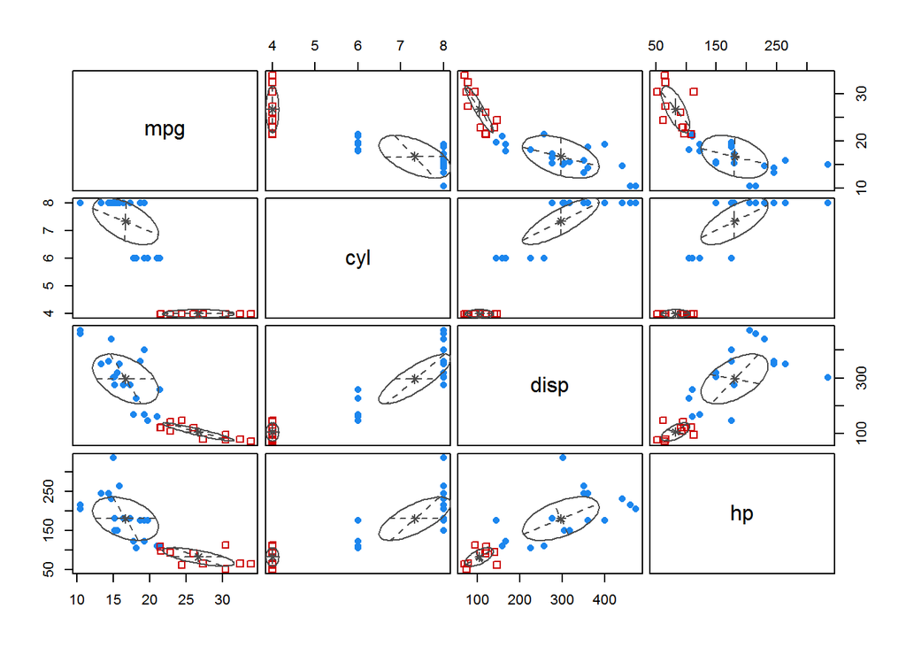

```r
# Select 4 variables and look for two distinct groups.
mcl.model2 <- Mclust(mtcars[, 1:4], 2)
# Plot our results.
plot(mcl.model2, what = "classification", main = "Mclust Classification")
```

```r
summary(mcl.model2, parameters = TRUE)
```

```
## ----------------------------------------------------
## Gaussian finite mixture model fitted by EM algorithm
## ----------------------------------------------------
##
## Mclust VEV (ellipsoidal, equal shape) model with 2 components:
##
##  log-likelihood  n df       BIC       ICL
##       -441.2396 32 26 -972.5884 -972.5885
##
## Clustering table:
##  1  2
## 21 11
##
## Mixing probabilities:
##         1         2
## 0.6562527 0.3437473
##
## Means:
##            [,1]      [,2]
## mpg   16.647668  26.66362
## cyl    7.333319   4.00000
## disp 296.503892 105.13650
## hp   180.237663  82.63641
##
## Variances:
## [,,1]
##              mpg       cyl      disp         hp
## mpg    20.377806 -2.083964 -187.0257  -95.00445
## cyl    -2.083964  0.704741   61.5757   32.41658
## disp -187.025670 61.575702 8040.0058 2666.53302
## hp    -95.004449 32.416579 2666.5330 3087.12877
## [,,2]
##                mpg           cyl          disp            hp
## mpg   2.431842e+01  3.592669e-15 -1.516505e+02 -8.062733e+01
## cyl   3.592669e-15  2.281849e-02  8.498073e-14 -2.989074e-13
## disp -1.516505e+02  8.498073e-14  1.084431e+03  4.589193e+02
## hp   -8.062733e+01 -2.989074e-13  4.589193e+02  5.501349e+02
```

Lo mismo para 3 grupos:

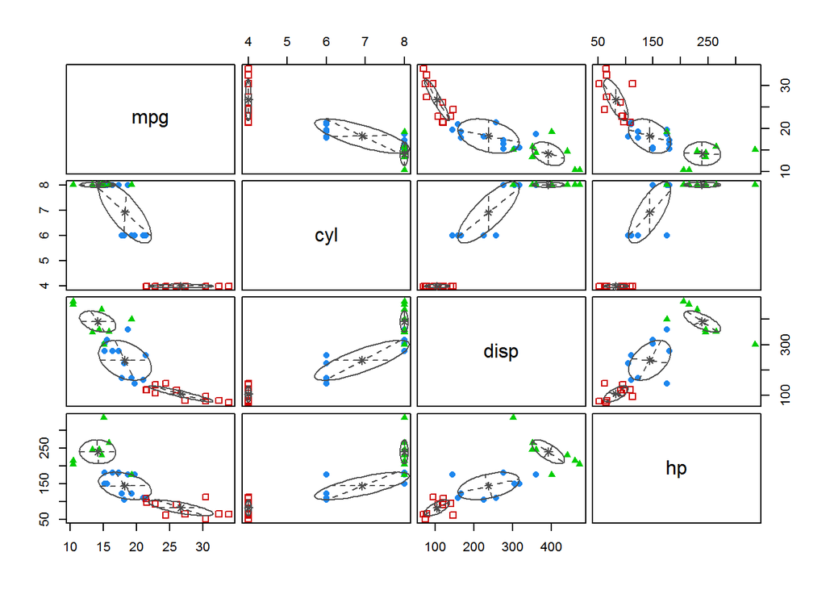

```r
# Select 4 continuous variables and look for three distinct groups.
mcl.model3 <- Mclust(mtcars[, 1:4], 3)
# Plot our results.
plot(mcl.model3, what = "classification", main = "Mclust Classification")
```

```r
summary(mcl.model3, parameters = TRUE)
```

```
## ----------------------------------------------------
## Gaussian finite mixture model fitted by EM algorithm
## ----------------------------------------------------
##
## Mclust VEV (ellipsoidal, equal shape) model with 3 components:
##
##  log-likelihood  n df       BIC      ICL
##       -400.9555 32 38 -933.6089 -933.968
##
## Clustering table:
##  1  2  3
## 13 11  8
##
## Mixing probabilities:
##         1         2         3
## 0.4079950 0.3424652 0.2495397
##
## Means:
##            [,1]      [,2]      [,3]
## mpg   18.231881  26.65226  14.12455
## cyl    6.915087   4.00000   8.00000
## disp 237.817823 105.15579 391.44542
## hp   143.840922  82.54609 239.36851
##
## Variances:
## [,,1]
##              mpg       cyl       disp         hp
## mpg    15.793924 -3.631946 -114.36112  -56.15351
## cyl    -3.631946  1.472453   76.48033   34.10442
## disp -114.361115 76.480329 6238.83807 1332.27287
## hp    -56.153510 34.104423 1332.27287 1463.32165
## [,,2]
##                mpg           cyl          disp            hp
## mpg   2.367334e+01 -2.137851e-15 -1.446445e+02 -7.834450e+01
## cyl  -2.137851e-15  5.483976e-03 -3.147783e-14  1.241113e-13
## disp -1.446445e+02 -3.147783e-14  1.025819e+03  4.612370e+02
## hp   -7.834450e+01  1.241113e-13  4.612370e+02  4.871843e+02
## [,,3]
##                mpg           cyl          disp            hp
## mpg   7.481203e+00  2.757048e-15 -4.445916e+01 -4.738462e+00
## cyl   2.757048e-15  1.024472e-02  4.380848e-13 -5.136234e-13
## disp -4.445916e+01  4.380848e-13  1.759244e+03 -9.640200e+02
## hp   -4.738462e+00 -5.136234e-13 -9.640200e+02  1.103969e+03
```

Y finalmente para 4 grupos:

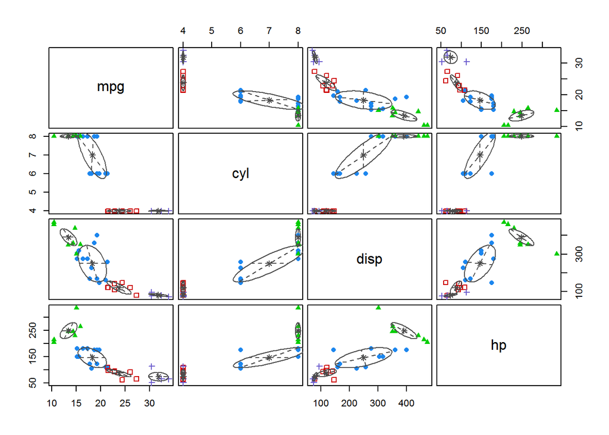

```r
# Select 4 continuous variables and look for four distinct groups.
mcl.model4 <- Mclust(mtcars[, 1:4], 4)
# Plot our results.
plot(mcl.model4, what = "classification", main = "Mclust Classification")
```

```r
summary(mcl.model4, parameters = TRUE)
```

```
## ----------------------------------------------------
## Gaussian finite mixture model fitted by EM algorithm
## ----------------------------------------------------
##
## Mclust VEV (ellipsoidal, equal shape) model with 4 components:
##
##  log-likelihood  n df       BIC       ICL
##       -378.1838 32 50 -929.6544 -929.6895
##
## Clustering table:
##  1  2  3  4
## 14  7  7  4
##
## Mixing probabilities:
##         1         2         3         4
## 0.4379371 0.2183909 0.2187500 0.1249220
##
## Means:
##            [,1]      [,2]      [,3]     [,4]
## mpg   18.271438  23.74236  13.41429 31.77498
## cyl    6.997005   4.00000   8.00000  4.00000
## disp 249.351827 119.37603 390.57143 80.15650
## hp   146.077391  87.57006 248.42856 74.01846
##
## Variances:
## [,,1]
##              mpg       cyl      disp         hp
## mpg     8.479944  -2.65837 -112.2493  -52.99919
## cyl    -2.658370   1.57882  106.4526   38.57022
## disp -112.249347 106.45259 9813.6562 2140.23216
## hp    -52.999186  38.57022 2140.2322 1458.94256
## [,,2]
##                mpg           cyl          disp            hp
## mpg   6.151537e+00  8.578366e-15 -7.337206e+01 -2.851441e+01
## cyl   8.578366e-15  3.781652e-03 -1.757071e-13 -2.244549e-14
## disp -7.337206e+01 -1.757071e-13  1.263261e+03  2.920593e+02
## hp   -2.851441e+01 -2.244549e-14  2.920593e+02  1.965819e+02
## [,,3]
##                mpg           cyl          disp            hp
## mpg   2.980438e+00  8.481234e-15 -5.062857e+01  2.848080e+01
## cyl   8.481234e-15  7.663014e-03  4.608899e-13 -2.433976e-13
## disp -5.062857e+01  4.608899e-13  2.038258e+03 -1.104063e+03
## hp    2.848080e+01 -2.433976e-13 -1.104063e+03  9.294044e+02
## [,,4]
##                mpg           cyl          disp            hp
## mpg   3.906775e+00 -2.318398e-15 -1.108485e+01 -3.398305e+00
## cyl  -2.318398e-15  8.561554e-04 -2.277514e-15 -2.871376e-14
## disp -1.108485e+01 -2.277514e-15  5.736859e+01  9.040441e+01
## hp   -3.398305e+00 -2.871376e-14  9.040441e+01  2.706217e+02
```

Pareciera que para 4 grupos, el modelo incorpora la mayor cantidad de componentes en los grafos ?.

La libreria mtclust tiene la capacidad de seleccionar el modelo que considera óptimo para un dataset dado, vamos a aplicarlo en nuetro ejemplo, para esto no le indicamos el valor ‘k’, dejamos que lo determine automáticamente:

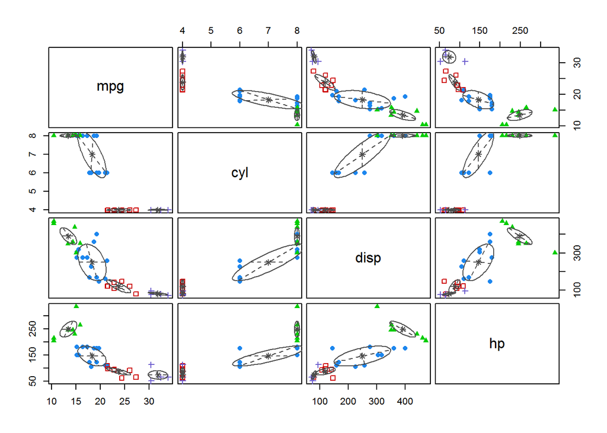

```r
# Select 4 continuous variables.
mcl.modelx <- Mclust(mtcars[, 1:4])
# Plot our results.
plot(mcl.modelx, what = "classification", main = "Mclust Classification")
```

```r
summary(mcl.modelx)
```

```
## ----------------------------------------------------
## Gaussian finite mixture model fitted by EM algorithm
## ----------------------------------------------------
##
## Mclust VEV (ellipsoidal, equal shape) model with 4 components:
##
##  log-likelihood  n df       BIC       ICL
##       -378.1838 32 50 -929.6544 -929.6895
##
## Clustering table:
##  1  2  3  4
## 14  7  7  4
```

El algoritmo de ajuste selecciona como mejor modelo el formado por 4 clusters, los cuales tendrian forma elipsoidal y de igual forma para las variables involucradas.

Ahora vamos dejar que lo determine automaticamente pero vamos a incorporar una variante, vamos a normalizar los datos:

```r
mtcars.normal = as.data.frame(scale(mtcars[,1:4]))
```

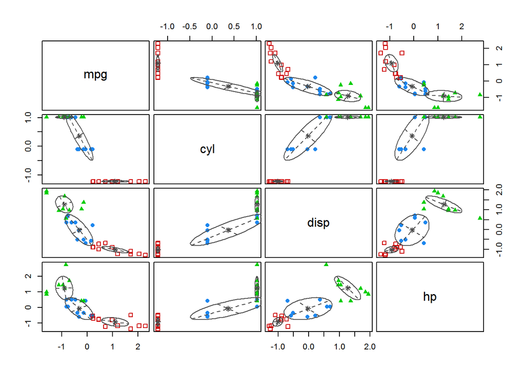

```r
# Select 4 continuous variables.
mcl.normal_modelx <- Mclust(mtcars.normal[, 1:4])
# Plot our results.
plot(mcl.normal_modelx, what = "classification", main = "Mclust Classification")
```

```r
summary(mcl.normal_modelx)
```

```
## ----------------------------------------------------
## Gaussian finite mixture model fitted by EM algorithm
## ----------------------------------------------------
##
## Mclust VEV (ellipsoidal, equal shape) model with 3 components:
##
##  log-likelihood  n df       BIC      ICL
##        -25.1517 32 38 -182.0014 -182.026
##
## Clustering table:
##  1  2  3
## 12 11  9
```

Al normalizar los datos, el algoritmo seleccion un modelo de 3 clusters, que dan como resultados grafos de forma elipsoidal y todos ellos de igual forma.

## Clustering K-means

Se trata de un algoritmo no supervisado que busca en las observaciones grupos con características similares y diferentes a otros grupos. Esto es maximizar la variación inter-cluster, y minimizar la intra-cluster. Entre sus ventajas se encuentra que es económico, de almacenamiento reducido, ya que solo guarda los clusters, en cuanto a sus desventajas es la necesidad de probar para determinar el mejor número de clusters, ademas se puede encontrar influenciado por los outliers.

Vamos a aplicar el algoritmo k-means, en este caso vamos a trabajar las primeras cuatro variables:

mpg: Miles/(US) gallon, millas por galon. cyl: Number of cylinders, número de cilindradas. disp: Displacement (cu.in.), desplazamiento. hp: Gross horsepower, potencia bruta.

```r
mtcars[,1:4]
```

|  | mpg | cyl | disp | hp |
| --- | --- | --- | --- | --- |
| Mazda RX4 | 21.0 | 6 | 160.0 | 110 |
| Mazda RX4 Wag | 21.0 | 6 | 160.0 | 110 |
| Datsun 710 | 22.8 | 4 | 108.0 | 93 |
| Hornet 4 Drive | 21.4 | 6 | 258.0 | 110 |
| Hornet Sportabout | 18.7 | 8 | 360.0 | 175 |
| Valiant | 18.1 | 6 | 225.0 | 105 |
| Duster 360 | 14.3 | 8 | 360.0 | 245 |
| Merc 240D | 24.4 | 4 | 146.7 | 62 |
| Merc 230 | 22.8 | 4 | 140.8 | 95 |
| Merc 280 | 19.2 | 6 | 167.6 | 123 |

[output cut: 22 more lines]

Como los datos se encuentra sin normalizar, podria pasar que cyl por ejemplo, tenga menos peso que el resto de las variables. Normalizamos el dataset para que todas las variables tengan igual peso:

```r
mtcars.normal = as.data.frame(scale(mtcars[,1:4]))
```

Seteamos una semilla para reproducir el experimento y clusterizamos, en este ejemplo vamos a trabajar con 4 clusters:

```r
set.seed(5)
mtcars.km <- kmeans(mtcars.normal[, 1:4], centers = 4)
mtcars.km
```

```
## K-means clustering with 4 clusters of sizes 11, 7, 7, 7
##
## Cluster means:
##           mpg        cyl       disp         hp
## 1  1.09060362 -1.2248578 -1.0132874 -0.9341957
## 2 -0.05770215 -0.1049878 -0.3825084 -0.3559038
## 3 -0.54835560  1.0148821  0.6850701  0.3400164
## 4 -1.10774794  1.0148821  1.2897470  1.4839092
##
## Clustering vector:
##           Mazda RX4       Mazda RX4 Wag          Datsun 710
##                   2                   2                   1
##      Hornet 4 Drive   Hornet Sportabout             Valiant
##                   2                   3                   2
##          Duster 360           Merc 240D            Merc 230
##                   4                   1                   1
##            Merc 280           Merc 280C          Merc 450SE
##                   2                   2                   3
##          Merc 450SL         Merc 450SLC  Cadillac Fleetwood
##                   3                   3                   4
## Lincoln Continental   Chrysler Imperial            Fiat 128
##                   4                   4                   1
##         Honda Civic      Toyota Corolla       Toyota Corona
##                   1                   1                   1
##    Dodge Challenger         AMC Javelin          Camaro Z28
##                   3                   3                   4
##    Pontiac Firebird           Fiat X1-9       Porsche 914-2
##                   3                   1                   1
##        Lotus Europa      Ford Pantera L        Ferrari Dino
##                   1                   4                   2
##       Maserati Bora          Volvo 142E
##                   4                   1
##
## Within cluster sum of squares by cluster:
## [1] 7.001553 1.774975 1.611893 4.852473
##  (between_SS / total_SS =  87.7 %)
##
## Available components:
##
## [1] "cluster"      "centers"      "totss"        "withinss"
## [5] "tot.withinss" "betweenss"    "size"         "iter"
## [9] "ifault"
```

```
totss: Inercia total, inercia de los grupos respecto del centroide de todos los grupos
betweenss: Inercia entre grupos (inter-grupos), deberia ser la mayor posible (asegura heterogenidad)
withinss: Inercia intra-grupos
tot.withinss: la suma de las inercias intra-grupos
```

Podemos observar el contenido del objeto por secciones:

```r
# centros:
mtcars.km$centers
```

```
##           mpg        cyl       disp         hp
## 1  1.09060362 -1.2248578 -1.0132874 -0.9341957
## 2 -0.05770215 -0.1049878 -0.3825084 -0.3559038
## 3 -0.54835560  1.0148821  0.6850701  0.3400164
## 4 -1.10774794  1.0148821  1.2897470  1.4839092
```

```r
# Inercia total:
mtcars.km$totss
```

```
## [1] 124
```

```r
# Inercia entre grupos:
mtcars.km$betweenss
```

```
## [1] 108.7591
```

```r
# Inercia intra-grupos:
mtcars.km$withinss
```

```
## [1] 7.001553 1.774975 1.611893 4.852473
```

Interaremos graficar los resultados, visualizando las cuatro variables que seleccionamos para el experimento en función de los clusters:

```r
table(mtcars.km$cluster, mtcars$mpg, mtcars$cyl, mtcars$disp, mtcars$hp)
```

[output not shown]

[output cut: 14944 more lines]

[output not shown]

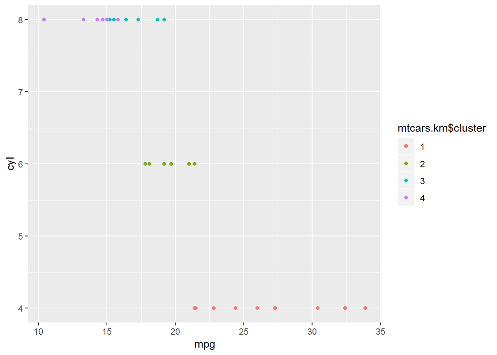

```r
library(ggplot2)
mtcars.km$cluster <- as.factor(mtcars.km$cluster)
ggplot(mtcars, aes(mpg, cyl, disp, hp, color = mtcars.km$cluster)) + geom_point()
```

#### Determinación del número de clusters óptimos

Como explicamos mas arriba, el algoritmo busca entre otras cosas, maximizar las variaciones entre grupos. Con lo cual podemos almacenar en un vector estos valores (betweens) para n valores de cluster:

```r
#Vector que almacena los valores inter-grupos:
subInterg<- kmeans(mtcars.normal, centers = 1)$betweenss
```

```r
#Vector con betweenss para cada cluster
for (i in 2:10) subInterg[i]<-kmeans(mtcars.normal, centers = i)$betweenss
```

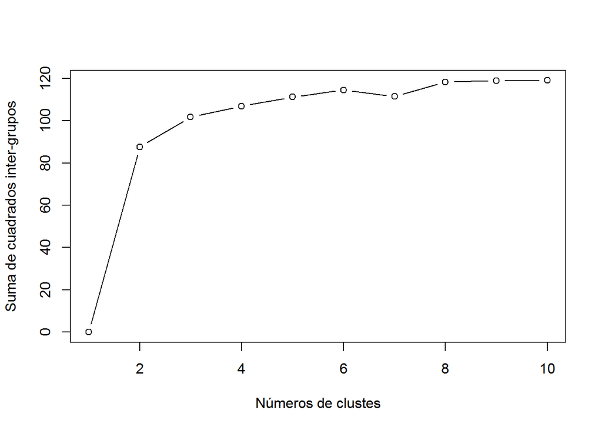

```r
#Graficamos los variaciones inter-grupo
plot(1:10, subInterg, type='b', xlab = "Números de clustes", ylab = "Suma de cuadrados inter-grupos")
```

Un valor de 4 o 6 podria ser un valor válido para nuestro ejemplo. Si ahora probamos con 6 centros:

```r
set.seed(5)
mtcars.km6 <- kmeans(mtcars.normal[, 1:4], centers = 6)
mtcars.km6
```

```
## K-means clustering with 6 clusters of sizes 11, 6, 7, 5, 2, 1
##
## Cluster means:
##           mpg        cyl       disp         hp
## 1  1.09060362 -1.2248578 -1.0132874 -0.9341957
## 2 -0.05651700 -0.1049878 -0.3309852 -0.4840448
## 3 -0.54835560  1.0148821  0.6850701  0.3400164
## 4 -1.23953698  1.0148821  1.4981449  1.1859553
## 5 -0.77827533  1.0148821  0.7687521  2.2287939
## 6 -0.06481307 -0.1049878 -0.6916474  0.4129422
##
## Clustering vector:
##           Mazda RX4       Mazda RX4 Wag          Datsun 710
##                   2                   2                   1
##      Hornet 4 Drive   Hornet Sportabout             Valiant
##                   2                   3                   2
##          Duster 360           Merc 240D            Merc 230
##                   4                   1                   1
##            Merc 280           Merc 280C          Merc 450SE
##                   2                   2                   3
##          Merc 450SL         Merc 450SLC  Cadillac Fleetwood
##                   3                   3                   4
## Lincoln Continental   Chrysler Imperial            Fiat 128
##                   4                   4                   1
##         Honda Civic      Toyota Corolla       Toyota Corona
##                   1                   1                   1
##    Dodge Challenger         AMC Javelin          Camaro Z28
##                   3                   3                   4
##    Pontiac Firebird           Fiat X1-9       Porsche 914-2
##                   3                   1                   1
##        Lotus Europa      Ford Pantera L        Ferrari Dino
##                   1                   5                   6
##       Maserati Bora          Volvo 142E
##                   5                   1
##
## Within cluster sum of squares by cluster:
## [1] 7.0015531 0.9737769 1.6118925 1.6085551 0.6263632 0.0000000
##  (between_SS / total_SS =  90.5 %)
##
## Available components:
##
## [1] "cluster"      "centers"      "totss"        "withinss"
## [5] "tot.withinss" "betweenss"    "size"         "iter"
## [9] "ifault"
```

```r
table(mtcars.km6$cluster, mtcars$mpg, mtcars$cyl, mtcars$disp, mtcars$hp)
```

[output not shown]

[output cut: 12613 more lines]

[output not shown]

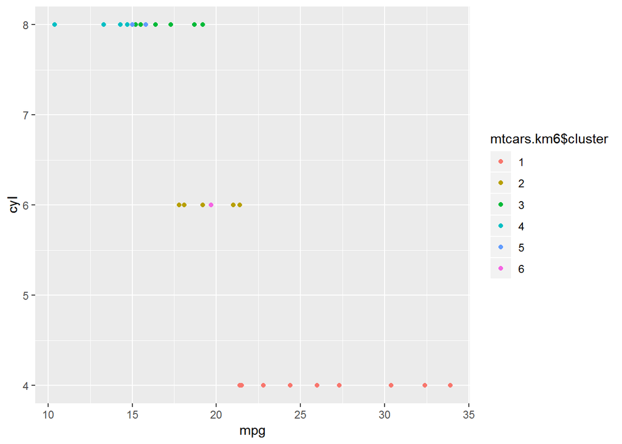

```r
library(ggplot2)
mtcars.km6$cluster <- as.factor(mtcars.km6$cluster)
ggplot(mtcars, aes(mpg, cyl, disp, hp, color = mtcars.km6$cluster)) + geom_point()
```

Al aplicar 6 centros, ahora aparecen nuevas features en el centro y en la parte superior.

Es importante, notar que debieramos trabajar con el experto en el dataset para poder analizar, interpretar y aplicar el feedback necesario en cada caso. Sin embargo, estos ejemplos nos ayudado a tener una idea del funcionamiento de los algoritmo y el potencial detras de ellos.